# Analiza baterii

Ewelina Tyma

2024-12-10

# 1 Wstęp

**Bateria** – wieś na Białorusi, w obwodzie brzeskim. Mimo, że jest to na pewno ciekawe miejsce to nie o tym będzie poniższy raport.

Bateria jest to nieodłączny element naszego życia, używane są one do zasilania, telefonów, laptopów i innych urządzeń z których korzytamy na codzień. Składa się z kilku połączonych ogniw galwanicznych, z których każde ma swoje zadanie. Każde ogniwo zawiera dwie elektrody: anodę i katodę, które wykonane są z różnych materiałów. Elektrolit, czyli substancja przewodząca, umożliwia przepływ jonów między elektrodami. Bez tego elementu bateria nie mogłaby działać. Anoda zazwyczaj składa się z metalu, który łatwo oddaje elektrony, natomiast katoda przyjmuje te elektrony, zamykając obwód elektryczny.

# 2 Dane

## 2.1 Zawartość zbioru danych

Analizowane dane dostępne są dzięki Departamentowi Energii USA w ramach inicjatywy naukowej Material Project. Dzięki udostępnieniu danych dotycząych struktury, właściwości i potencjalnych zastosowań materiałów badania w dziedzinach: elektronika, fotonika i magazynowanie energii są bardziej dostępne i mogą prowadzić do rozwoju tych dziedzin.  
Zanim przejdziemy do analizowania danych przyjrzymy się w jakie dane są dostępne i w jaki sposób. Poniżej znajduje się pięć pierwszych wierszy tabeli zawierających dane, które w dalszej części zostaną poddane analizie.

```r
bat <- read.csv(file = "C:/Users/eweli/Desktop/ZPD/projekt_baterie/mp_batteries.csv", header = TRUE, sep = ",")

knitr::kable(head(bat, 5))
```

| Battery.ID | Battery.Formula | Working.Ion | Formula.Charge | Formula.Discharge | Max.Delta.Volume | Average.Voltage | Gravimetric.Capacity | Volumetric.Capacity | Gravimetric.Energy | Volumetric.Energy | Atomic.Fraction.Charge | Atomic.Fraction.Discharge | Stability.Charge | Stability.Discharge | Steps | Max.Voltage.Step |
| --- | --- | --- | --- | --- | --- | --- | --- | --- | --- | --- | --- | --- | --- | --- | --- | --- |
| mp-30_Al | Al0-2Cu | Al | Cu | Al2Cu | 3.043399 | 0.0890331 | 1368.481 | 5562.790 | 121.84009 | 495.27253 | 0.0 | 0.6666667 | 0.0000000 | 0.0000000 | 1 | 0 |
| mp-1022721_Al | Al1-3Cu | Al | AlCu | Al3Cu | 1.243653 | -0.0215863 | 1112.937 | 4418.980 | -24.02423 | -95.38962 | 0.5 | 0.7500000 | 0.0740612 | 0.0962458 | 1 | 0 |
| mp-8637_Al | Al0-5Mo | Al | Mo | Al5Mo | 4.762574 | 0.1227568 | 1741.504 | 7175.702 | 213.78156 | 880.86651 | 0.0 | 0.8333333 | 0.4114601 | 0.0452120 | 1 | 0 |
| mp-129_Al | Al0-12Mo | Al | Mo | Al12Mo | 12.723893 | 0.0431214 | 2298.811 | 7346.232 | 99.12801 | 316.78006 | 0.0 | 0.9230769 | 0.0000000 | 0.0114456 | 1 | 0 |
| mp-91_Al | Al0-12W | Al | W | Al12W | 12.494598 | 0.0292342 | 1900.745 | 7332.719 | 55.56677 | 214.36621 | 0.0 | 0.9230769 | 0.0000000 | 0.0000000 | 1 | 0 |

W danych mamy 17 kolumn zawierających następujące parametry:

1. **Battery ID**: Identyfikator baterii.
2. **Battery Formula**: Wzór chemiczny materiału baterii.
3. **Working Ion**: Główny jon, który odpowiada za transport ładunku w baterii.
4. **Formula Charge**: Wzór chemiczny materiału baterii w stanie naładowanym.
5. **Formula Discharge**: Wzór chemiczny materiału baterii w stanie rozładowanym.
6. **Max Delta Volume**: Zmiana objętości w % dla danego kroku napięcia za pomocą wzoru: max(charge, discharge)/min(charge, discharge) -1.
7. **Average Voltage**: Średnie napięcie dla poszczególnego kroku napięcia.
8. **Gravimetric Capacity**: Pojemność grawimetryczna, czyli ilość energii na jednostkę masy (mAh/g).
9. **Volumetric Capacity**: Pojemność wolumetryczna, czyli ilość energii na jednostkę objętości (mAh/cm³).
10. **Gravimetric Energy**: Gęstość energii w odniesieniu do masy baterii (Wh/kg).
11. **Volumetric Energy**: Gęstość energii w odniesieniu do objętości baterii (Wh/L).
12. **Atomic Fraction Charge**: Udział atomowy składników w stanie naładowanym.
13. **Atomic Fraction Discharge**: Udział atomowy składników w stanie rozładowanym.
14. **Stability Charge**: Wskaźnik stabilności materiału w stanie naładowanym.
15. **Stability Discharge**: Wskaźnik stabilności materiału w stanie rozładowanym.
16. **Steps**: Liczba odrębnych kroków napięcia od pełnego naładowania do rozładowania,oparta na stabilnych stanach pośrednich.
17. **Max Voltage Step**: Maksymalna bezwzględna różnica między sąsiednimi krokami napięcia.

### 2.1.1 Wartości puste w zbiorze danych

Zanim przejdziemy do analizy danych, należy sprawdzić czy zbiór danych ma jakieś braki i jeżeli je ma zastanowić się w jaki sposób możemy rozwiązać ten problem.

```r
knitr::kable(sapply(bat, function(x) sum(is.na(x))))
```

|  | x |
| --- | --- |
| Battery.ID | 0 |
| Battery.Formula | 0 |
| Working.Ion | 0 |
| Formula.Charge | 0 |
| Formula.Discharge | 0 |
| Max.Delta.Volume | 0 |
| Average.Voltage | 0 |
| Gravimetric.Capacity | 0 |
| Volumetric.Capacity | 0 |
| Gravimetric.Energy | 0 |
| Volumetric.Energy | 0 |
| Atomic.Fraction.Charge | 0 |
| Atomic.Fraction.Discharge | 0 |
| Stability.Charge | 0 |
| Stability.Discharge | 0 |
| Steps | 0 |
| Max.Voltage.Step | 0 |

Jak widać analizowany zbiór danych nie posiada pustych wartości. Można zatem przejść do analizy.

## 2.2 Podsumowanie zbioru danych

Poniżej znajduje się krótkie podsumowanie danych zawartych w tabeli.

```r
knitr::kable(summary(bat))
```

|  | Battery.ID | Battery.Formula | Working.Ion | Formula.Charge | Formula.Discharge | Max.Delta.Volume | Average.Voltage | Gravimetric.Capacity | Volumetric.Capacity | Gravimetric.Energy | Volumetric.Energy | Atomic.Fraction.Charge | Atomic.Fraction.Discharge | Stability.Charge | Stability.Discharge | Steps | Max.Voltage.Step |
| --- | --- | --- | --- | --- | --- | --- | --- | --- | --- | --- | --- | --- | --- | --- | --- | --- | --- |
|  | Length:4351 | Length:4351 | Length:4351 | Length:4351 | Length:4351 | Min. : 0.00002 | Min. :-7.755 | Min. : 5.176 | Min. : 24.08 | Min. :-583.5 | Min. :-2208.1 | Min. :0.00000 | Min. :0.007407 | Min. :0.00000 | Min. :0.00000 | Min. :1.000 | Min. : 0.0000 |
|  | Class :character | Class :character | Class :character | Class :character | Class :character | 1st Qu.: 0.01747 | 1st Qu.: 2.226 | 1st Qu.: 88.108 | 1st Qu.: 311.62 | 1st Qu.: 211.7 | 1st Qu.: 821.6 | 1st Qu.:0.00000 | 1st Qu.:0.086957 | 1st Qu.:0.03301 | 1st Qu.:0.01952 | 1st Qu.:1.000 | 1st Qu.: 0.0000 |
|  | Mode :character | Mode :character | Mode :character | Mode :character | Mode :character | Median : 0.04203 | Median : 3.301 | Median : 130.691 | Median : 507.03 | Median : 401.8 | Median : 1463.8 | Median :0.00000 | Median :0.142857 | Median :0.07319 | Median :0.04878 | Median :1.000 | Median : 0.0000 |
|  | NA | NA | NA | NA | NA | Mean : 0.37531 | Mean : 3.083 | Mean : 158.291 | Mean : 610.62 | Mean : 444.1 | Mean : 1664.0 | Mean :0.03986 | Mean :0.159077 | Mean :0.14257 | Mean :0.12207 | Mean :1.167 | Mean : 0.1503 |
|  | NA | NA | NA | NA | NA | 3rd Qu.: 0.08595 | 3rd Qu.: 4.019 | 3rd Qu.: 187.600 | 3rd Qu.: 722.75 | 3rd Qu.: 614.4 | 3rd Qu.: 2252.3 | 3rd Qu.:0.04762 | 3rd Qu.:0.200000 | 3rd Qu.:0.13160 | 3rd Qu.:0.09299 | 3rd Qu.:1.000 | 3rd Qu.: 0.0000 |
|  | NA | NA | NA | NA | NA | Max. :293.19322 | Max. :54.569 | Max. :2557.627 | Max. :7619.19 | Max. :5926.9 | Max. :18305.9 | Max. :0.90909 | Max. :0.993333 | Max. :6.48710 | Max. :6.27781 | Max. :6.000 | Max. :26.9607 |

# 3 Analiza atrybutów zbiotu danych

## 3.1 Parametry fizyczne baterii

Poniżej znajdują się histogramy dla parametrów fizycznych zawartych w zbiorze danych.

### 3.1.1 Pojemność

Gęstość energii grawimetrycznej, czasami określana jako energia właściwa, to dostępna energia na jednostkę masy substancji. Gęstość energii grawimetrycznej jest zwykle wyrażana w watogodzinach na kilogram (Wh/kg) lub megadżulach na kilogram (MJ/kg). Można ją wykorzystać do określenia pojemności baterii.

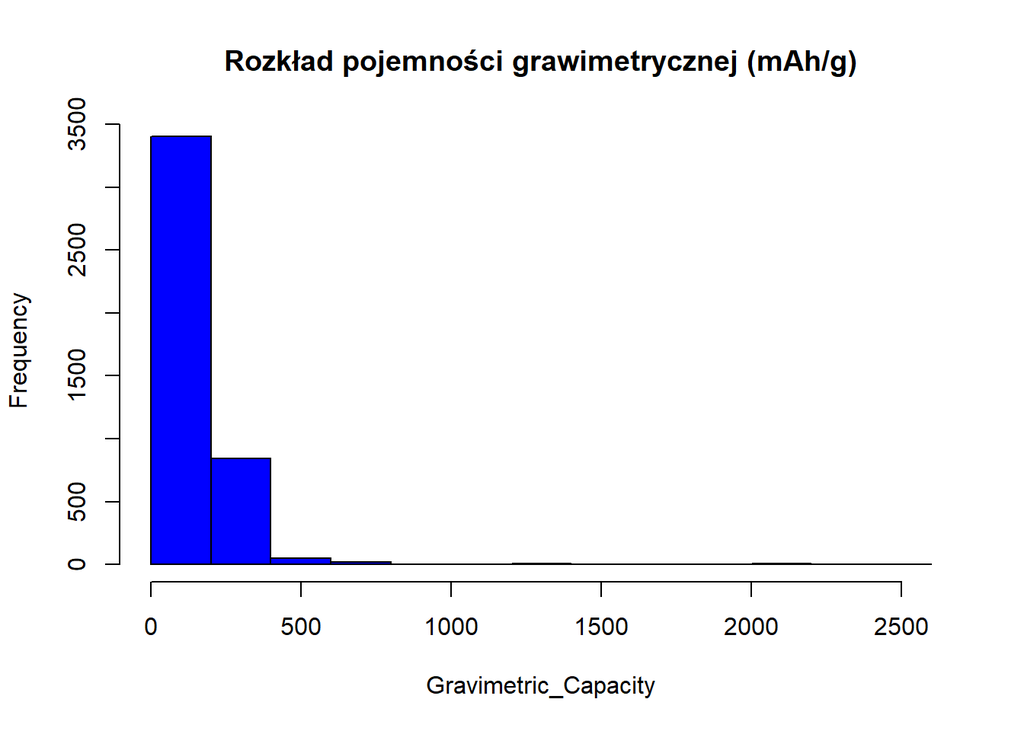

Objętościowa pojemność cieplna materiału to pojemność cieplna próbki substancji podzielona przez objętość próbki. Jest to ilość energii, którą należy dodać w postaci ciepła do jednej jednostki objętości materiału, aby spowodować wzrost jego temperatury o jedną jednostkę.

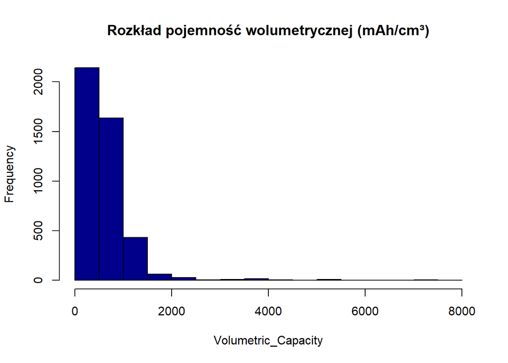

### 3.1.2 Gęstość energii

Jeżeli zbadamy ruch nośników prądu elektrycznego w baterii - elektronów swobodnych - to okazuje się, że nie jest on taki samy na całej powierzchni przekroju poprzecznego tej baterii. Z tej właśnie przyczyny wprowadza się wielkość fizyczną, która określa natężenie prądu przypadające na jednostkę masy lub objętości baterii.

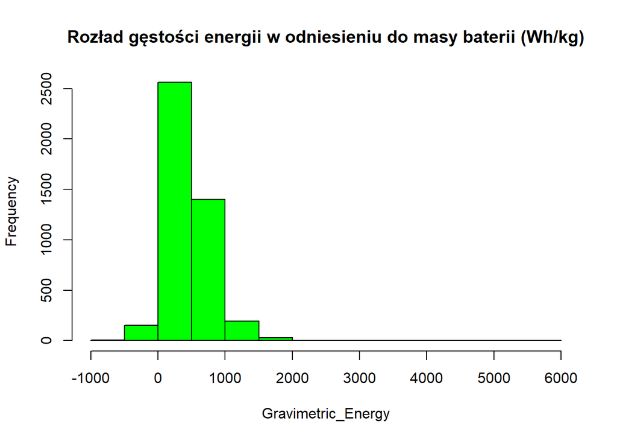

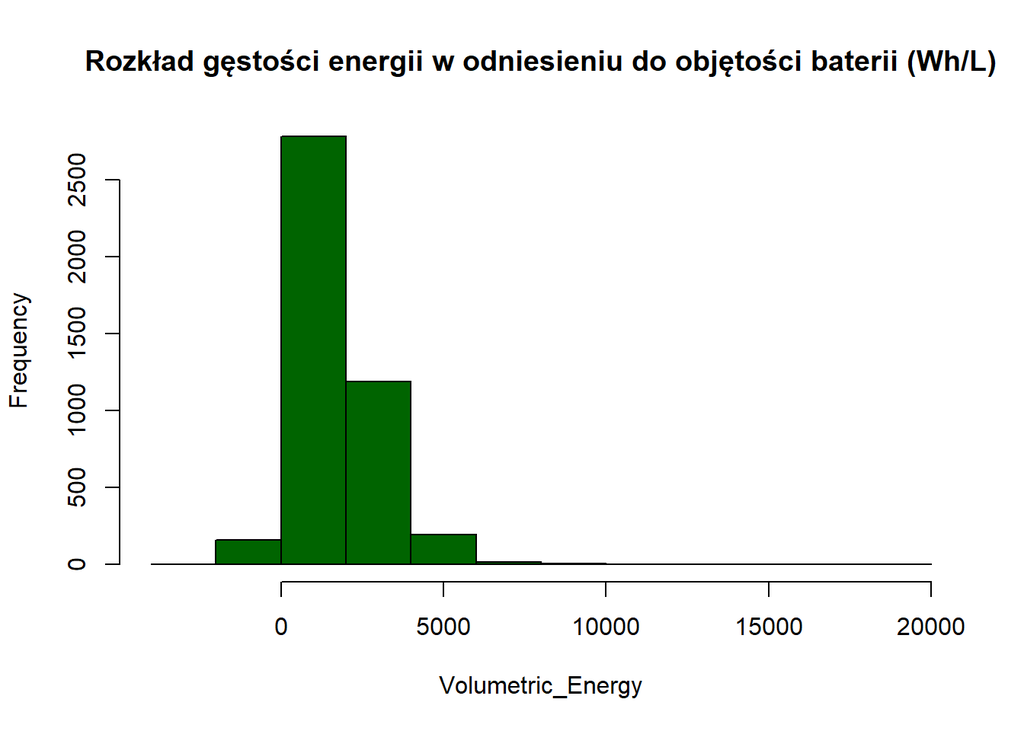

### 3.1.3 Udział atomowy składników

Bateria składa się zazwyczaj z trzech podstawowych elementów: anody (ujemnego bieguna), katody (dodatniego bieguna) oraz elektrolitu. Wszystkie są zrobione z różnych związków i pierwiastków chemicznych. To jakich konkretnie się użyje bezpośrednio wpływa na najistotniejsze charakterystki działania baterii - pojemność, trwałość itp.

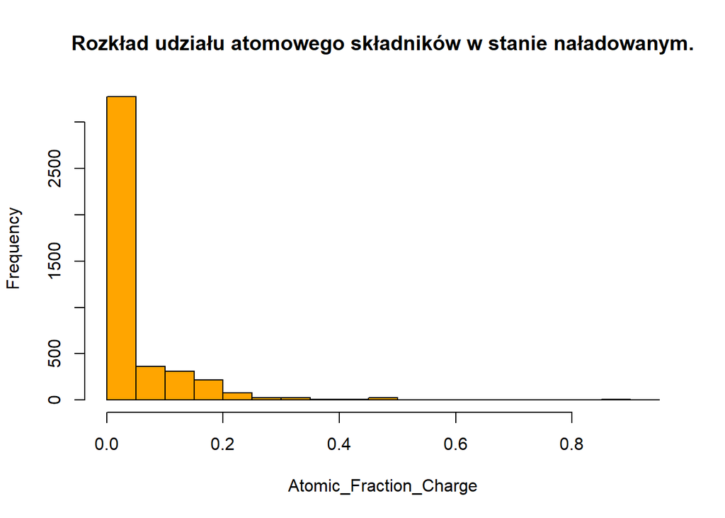

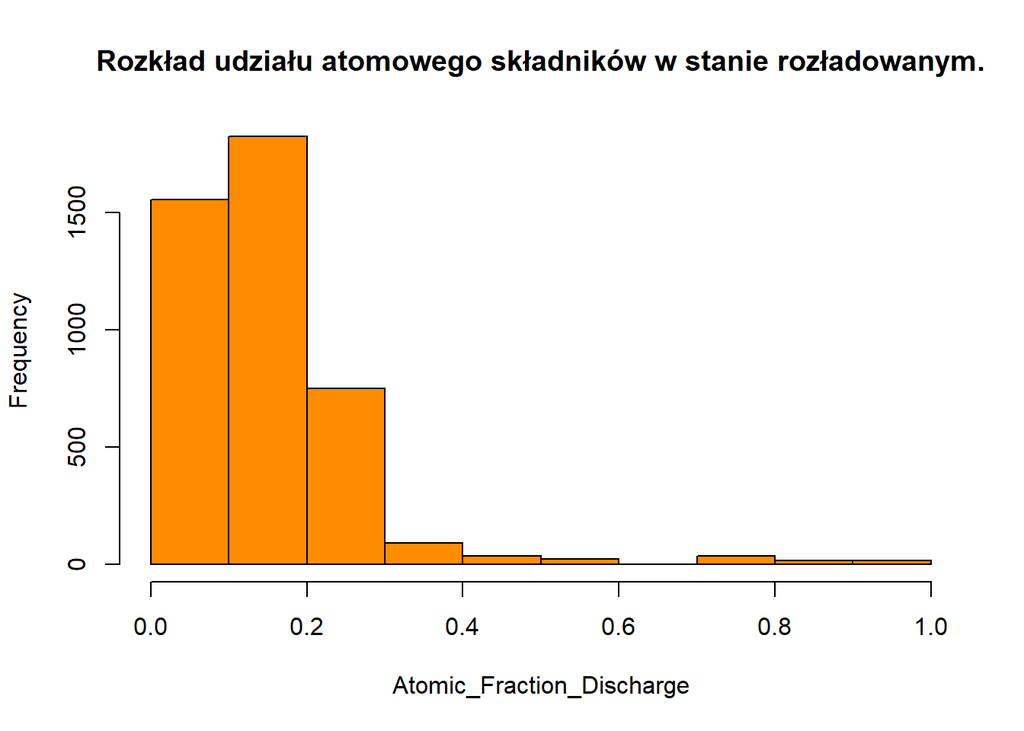

### 3.1.4 Wskaźnik stabilności materiału

Baterie jak już wcześniej zostało przedstawione mają bardzo zróżnicowane zastosowania w życiu codziennym. Dlatego ważne jest aby były one możliwe jak najbezpieczniejsze, a co za tym idzie by składniki chemiczne w nich wykorzystywane na każdym etapie użytkowania baterii były stabilne.

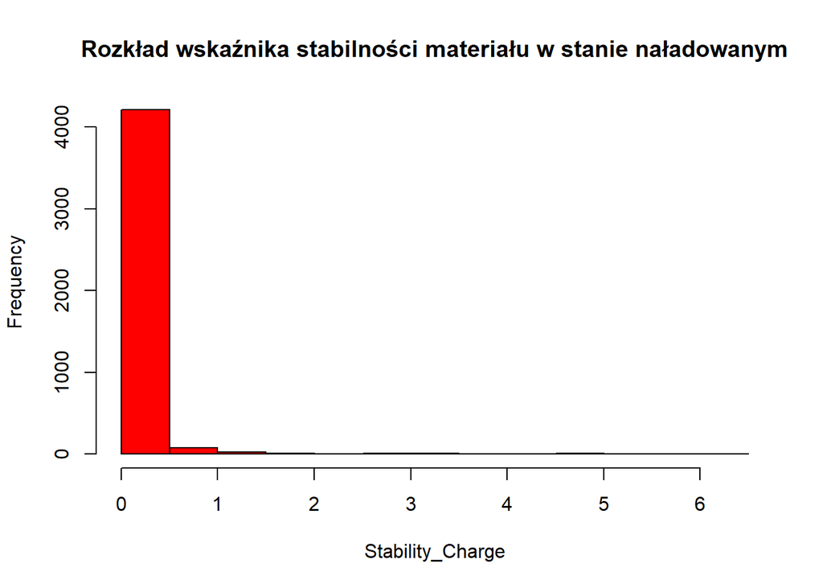

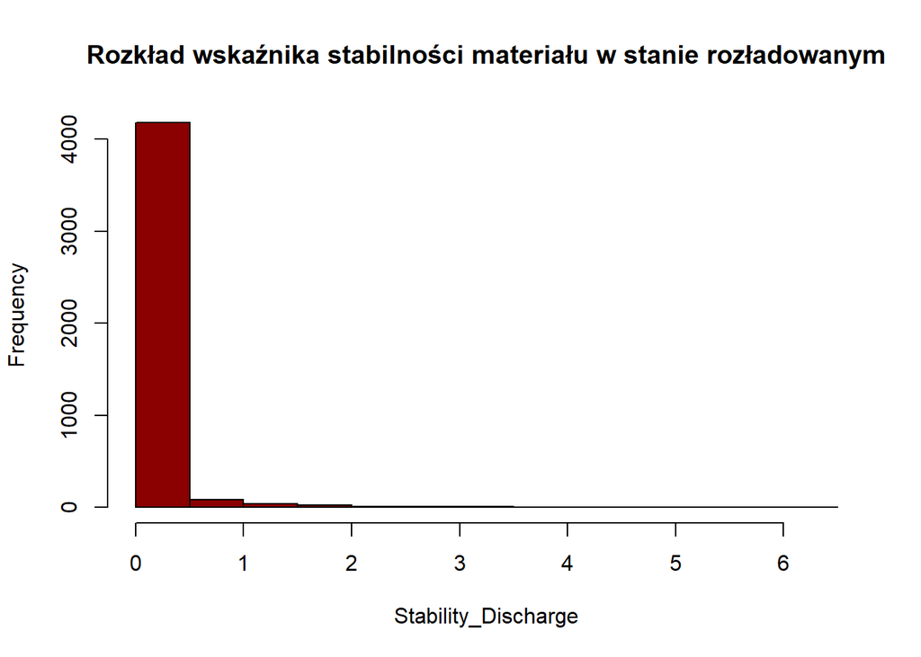

## 3.2 Parametry chemiczne baterii

W tej sekcji zajmiemy się przeanalizowaniem parametrów chemicznych baterii.

### 3.2.1 Sprawdzenie najczęściej występujących zmiennych w danej kategorii

Najpierw zastanówmy się jakie wartości najczęściej powtarzają się w ramach danej kategorii.

```r
for (i in colnames(bat[, 2:5])){
    np <- names(which.max(table(bat[[i]])))
    npl <- length(which(bat[[i]]==np))
    print(paste("Dla kolumny", i, "nazwa najczęściej występującego związku chemicznego to", np, "ilość powtórzeń wynosi", npl))
}
```

[output not shown]

Powyższy kod znajduje najczęściej występującą w danej kolumnie wartość wraz z ilością wystąpień. Dzięki temu wiemy że:

- Dla kolumny **Battery.Formula** nazwa najczęściej występującego związku chemicznego to **Li0-1V2OF5** ilość powtórzeń wynosi **19**.
- Dla kolumny **Working.Ion** nazwa najczęściej występującego pierwiastja chemicznego to **Li** ilość powtórzeń wynosi **2440**.
- Dla kolumny **Formula.Charge** nazwa najczęściej występującego związku chemicznego to **MnO2** ilość powtórzeń wynosi **49**.
- Dla kolumny **Formula.Discharge** nazwa najczęściej występującego związku chemicznego to **LiCoPO4** ilość powtórzeń wynosi **19**.

Widać, że najczęściej powtarzającą się wartością jest Li jako główny jon w baterii, występuje on w większości baterii ze zbioru.

### 3.2.2 Sprawdzenie wystąpień pierwiastków jako głównych jonów w baterii

Przeanalizujmy jak prezentuje się ilość różnych pierwiastków chemicznych będących głównymi jonami baterii.

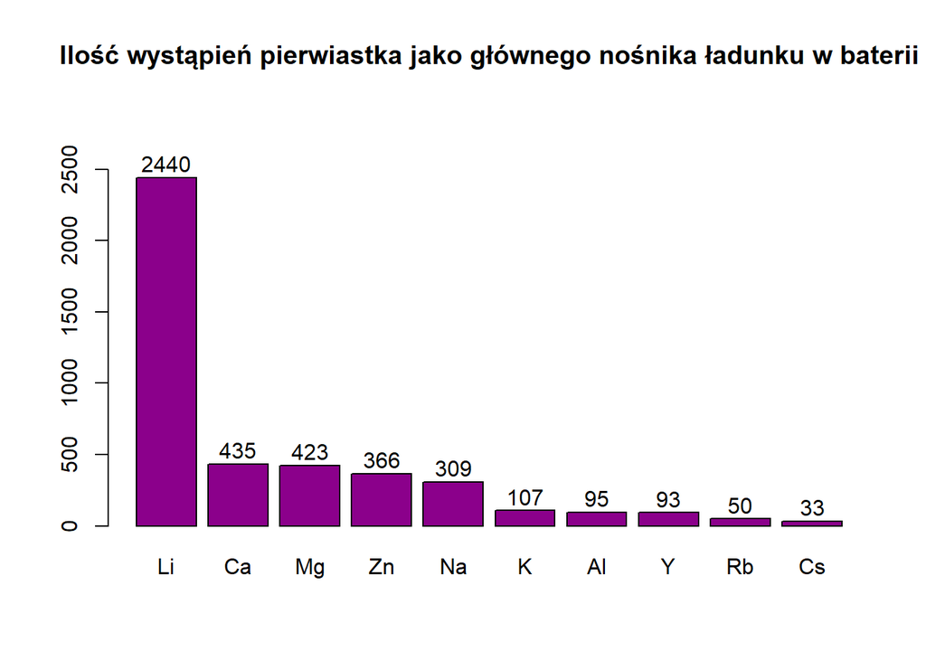

```r
a <- bat %>%
  count(Working.Ion)

b <- a[order(a$n,decreasing = TRUE),]

bar <- barplot(b[,2], names.arg=b[,1] , main ="Ilość wystąpień pierwiastka jako głównego nośnika ładunku w baterii",  ylim = c(0, max(b[,2]) * 1.2), col = "darkmagenta")

text(x = bar, y = b[,2] + 100, labels = b[,2])
```

Jak widać żaden z innych pierwiastków chemicznych nie jest nawet blisko ilości wystąpień litu. Jest to zrozumiałe ponieważ baterie litowe są aktualnie najpopularniejsze na rynku ze względu na ich następujące właściwości:

- Mają znacznie większą gęstość energetyczną w porównaniu do innych dostępnych na rynku rowiązań. Dzięki temu urządzenia z tymi bateriami mogą być mniejsze i lżejsze nie tracąc na parametrach pracy.
- Mają długi okres eksploracji. Są w stanie działać wiele lat i wielokrotnie być w tym czasie ładowane i rozładowywane. Co jest bardzo przydatne w między innymi telefonach czy latopach.
- Mają wysoką odporność na samorozładowywyanie. Są w stanie wytrzymywać długie okresy bez wytracania energii.
- Są w stanie szybko przyjąć dużą dawkę energii, a zatem można je szybko ładować.

# 4 Sprawdzanie korelacji między zmiennymi

W poniższej sekcji przeanalizujemy trzy najczęściej występujące pierwiastki chemiczne w kontekście wartości fizycznych.

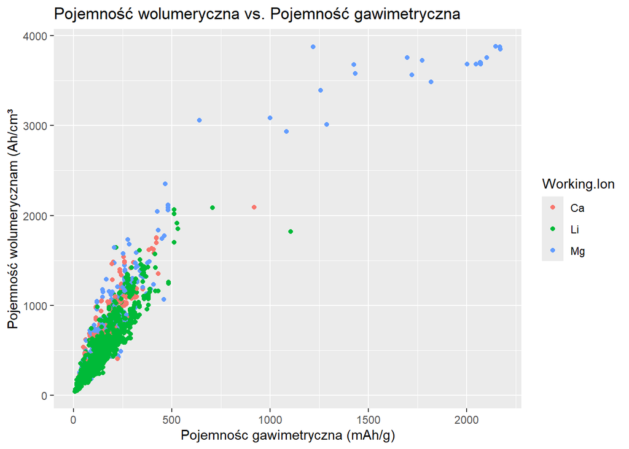

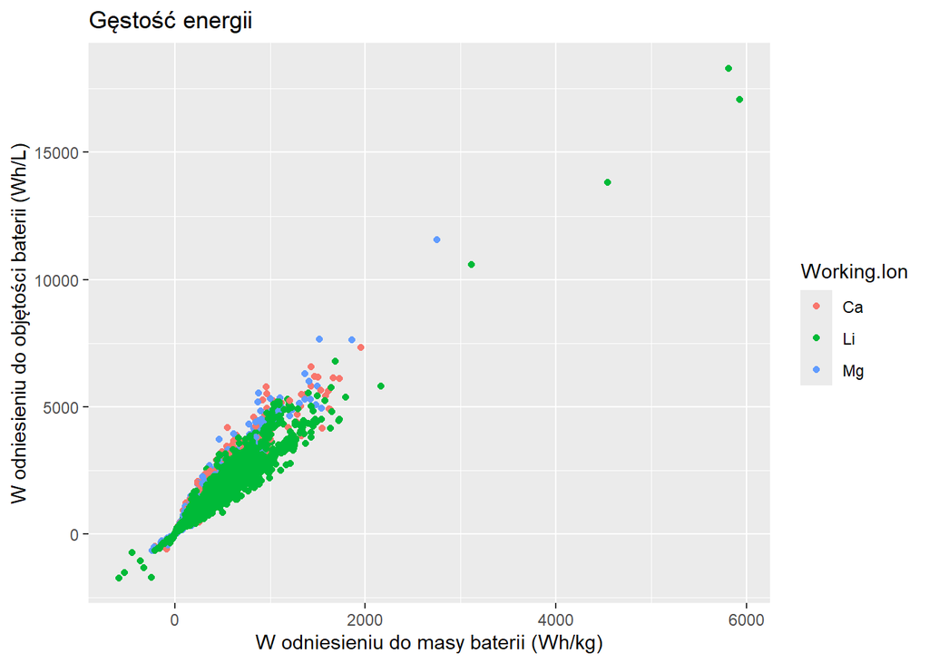

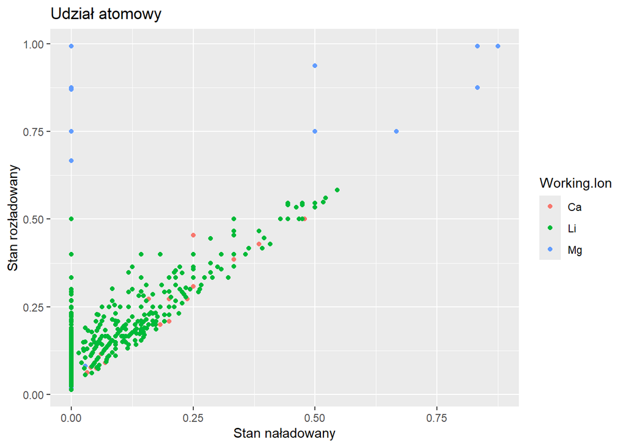

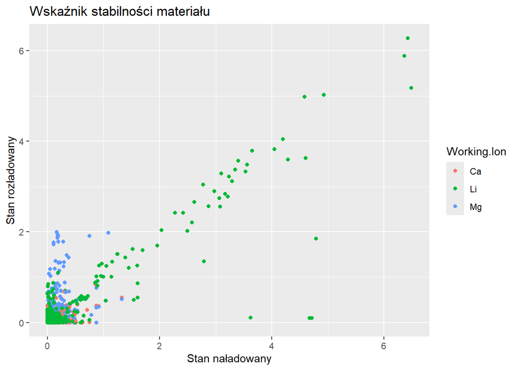

```r
a <- bat[(bat$Working.Ion == "Li")| (bat$Working.Ion == "Ca")| (bat$Working.Ion == "Mg"), ]

ggplot(a, aes(x = Gravimetric.Capacity, y = Volumetric.Capacity, colour = Working.Ion), ) +
  geom_point() +
  ggtitle("Pojemność wolumeryczna vs. Pojemność gawimetryczna") +
  xlab("Pojemnośc gawimetryczna (mAh/g)") +
  ylab("Pojemność wolumerycznam (Ah/cm³")
```